# Bugs

Non odiarmi

Ottavia

2022-11-09

# Intro

Sto provando a rompere il codice il più possibile.

## Summary errori

Ci sono problemi quando si prova a combianre diff_shapes() con altre regole. Nello specifico, se diff_shapes() è la regola applicata in orizzontale, la regola che dovrebbe essere applicata in verticale è applicata solo alla prima colonna (Sq1, Sq4, Sq7).

Viceversa, se diff_shapes() è la regola applicata in verticale, la regola che dovrebbe essere applicata in orizzontale è applicata solo sulla prima riga (Sq1, Sq2, Sq3)

# Rotation

## H - SI

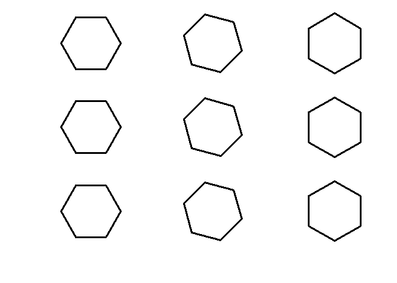

```r
rot_h <-apply(Raven(st1=cof(e.hexagon()),
                   hrule=c("rotation"),vrule=c("identity")))
draw(rot_h)
```

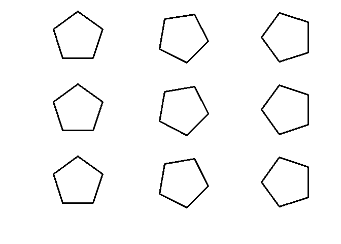

```r
rot_v <-apply(Raven(st1=cof(pentagon()),
                   hrule=c("rotation"),vrule=c("identity")))
draw(rot_v)
```

## HV - SI ( ma viene il mal di mare)

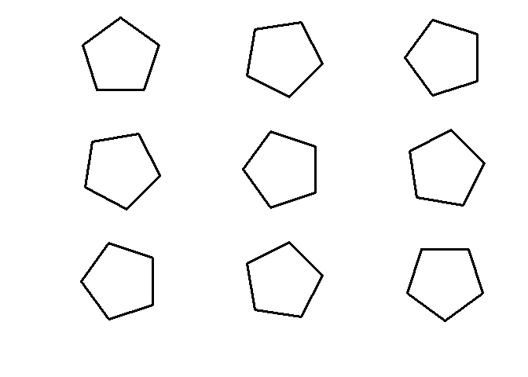

```r
rot_hv <-apply(Raven(st1=cof(pentagon()),
                   hrule=c("rotation"),vrule=c("rotation")))
draw(rot_hv)
```

# Size

## H - SI

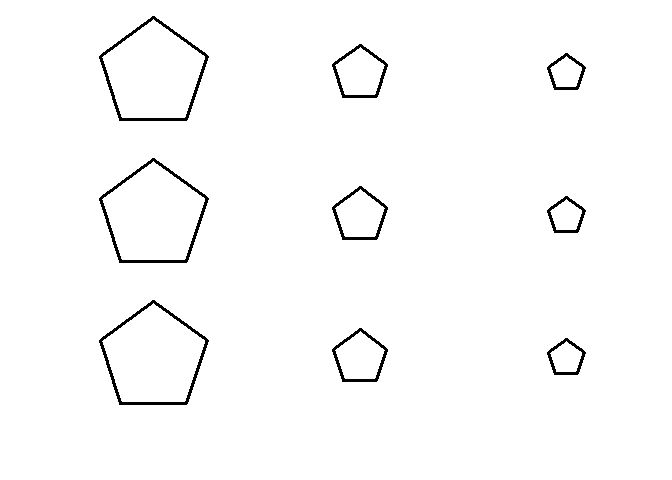

```r
s_h = apply(Raven(st1=pentagon(),
                  hrule=c("size"),
                  vrule=c("identity")))
draw(s_h)
```

## V - SI

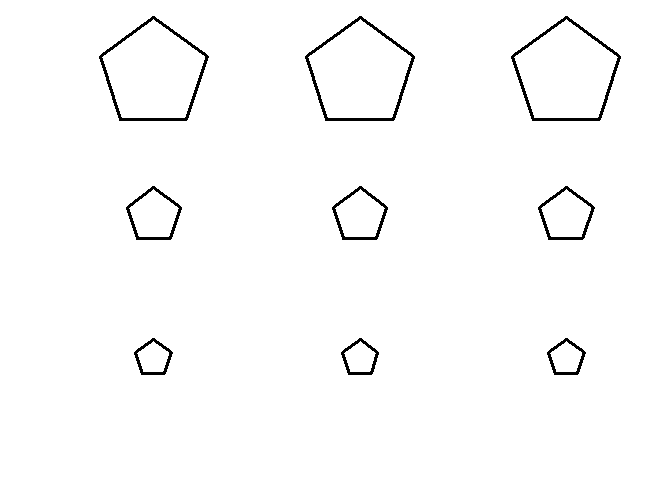

```r
s_v = apply(Raven(st1=pentagon(),
                  hrule=c("identity"),
                  vrule=c("size")))
draw(s_v)
```

## HV - SI

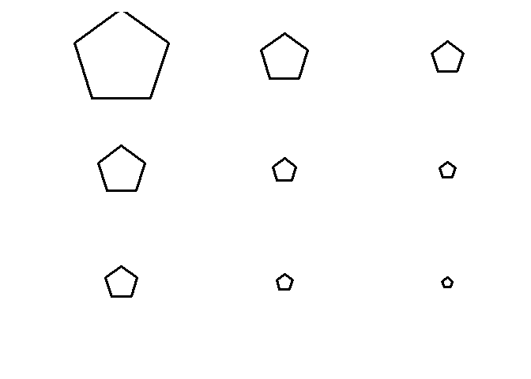

```r
s_hv = apply(Raven(st1=pentagon(),
                  hrule=c("size"),
                  vrule=c("size")))
draw(s_hv)
```

# Bordo - spessore

## H - SI

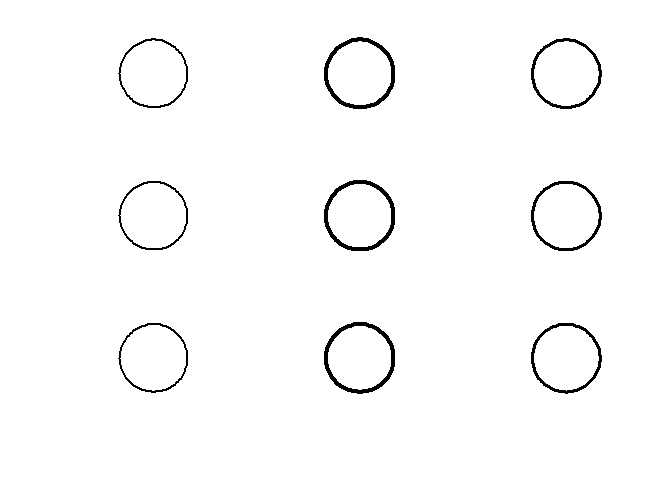

```r
lwd_h = apply(Raven(st1=circle(),
                  hrule=c("lwd"),
                  vrule=c("identity")))
draw(lwd_h)
```

## V - SI

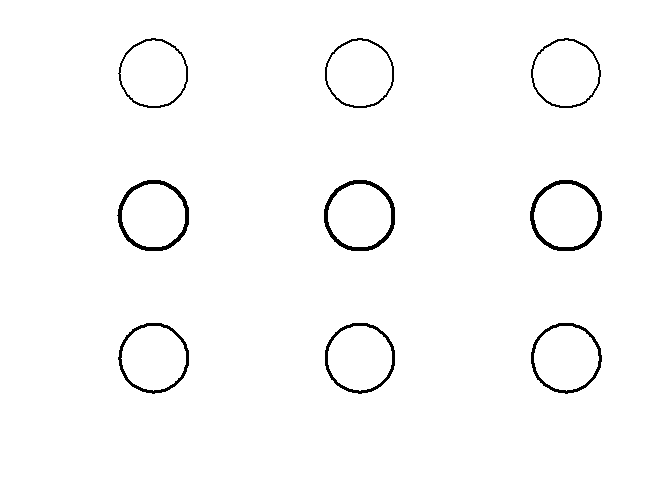

```r
lwd_v = apply(Raven(st1=circle(),
                  hrule=c("identity"),
                  vrule=c("lwd")))
draw(lwd_v)
```

## HV - SI

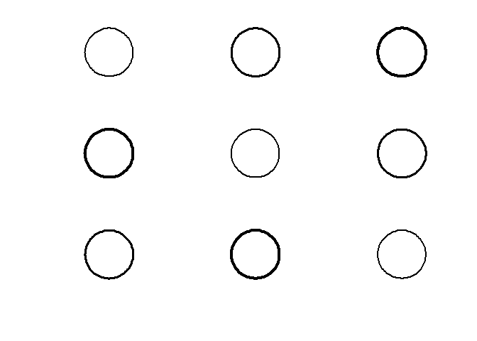

```r
lwd_hv = apply(Raven(st1=circle(),
                  hrule=c("lwd"),
                  vrule=c("lwd")))
draw(lwd_hv)
```

# Bordo - Tipo

## H - SI

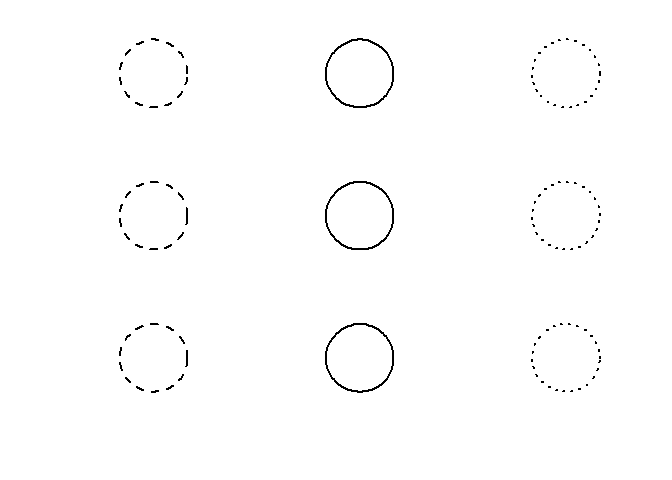

```r
lty_h = apply(Raven(st1=circle(),
                  hrule=c("lty"),
                  vrule=c("identity")))
draw(lty_h)
```

## V - SI

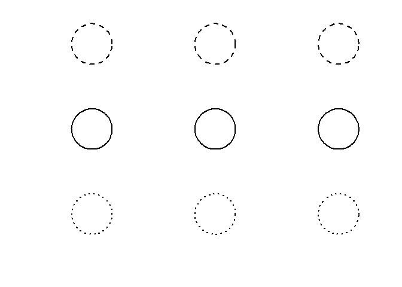

```r
lty_v = apply(Raven(st1=circle(),
                  hrule=c("identity"),
                  vrule=c("lty")))
draw(lty_v)
```

## HV - SI

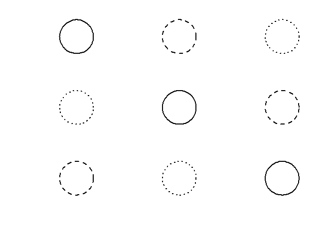

```r
lty_hv = apply(Raven(st1=circle(),
                  hrule=c("lty"),
                  vrule=c("lty")))
draw(lty_hv)
```

# Rotation * size

## HV - SI

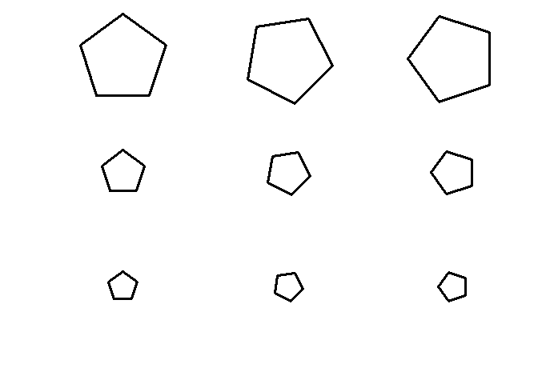

```r
rs_hv = apply(Raven(st1=pentagon(),
                  hrule=c("rotation"),
                  vrule=c("size")))
draw(rs_hv)
```

## VH - SI

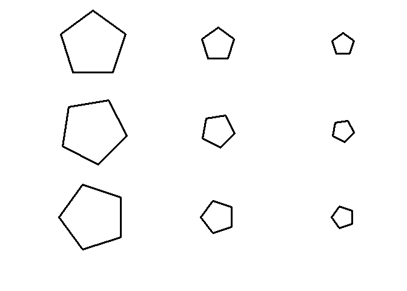

```r
rs_vh = apply(Raven(st1=pentagon(),
                  hrule=c("size"),
                  vrule=c("rotation")))
draw(rs_vh)
```

# LWD * Rotation

## HV - SI

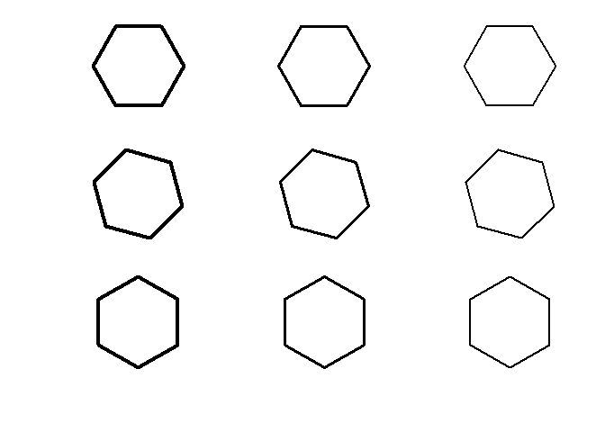

```r
lwdr_hv = apply(Raven(st1=e.hexagon(),
                  hrule=c("lwd"),
                  vrule=c("rotation")))
draw(lwdr_hv)
```

## VH - SI

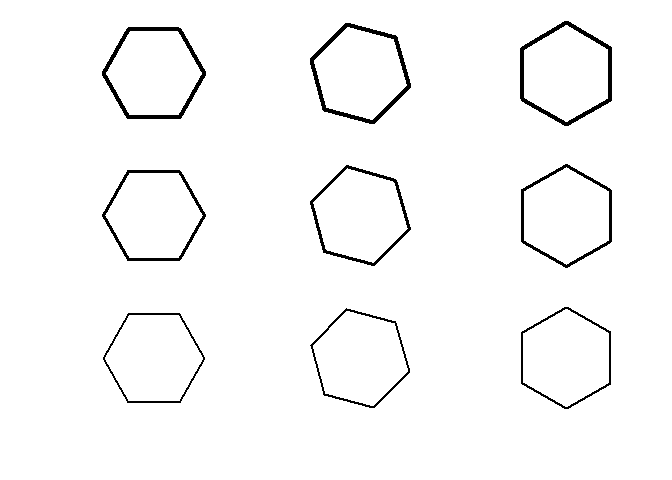

```r
lwdr_vh = apply(Raven(st1=e.hexagon(),
                  hrule=c("rotation"),
                  vrule=c("lwd")))
draw(lwdr_vh)
```

# LWD * size

## HV - SI

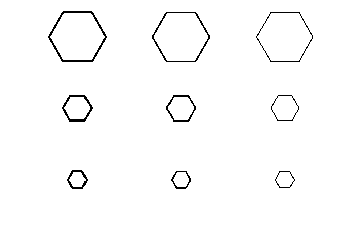

```r
lwds_hv = apply(Raven(st1=e.hexagon(),
                  hrule=c("lwd"),
                  vrule=c("size")))
draw(lwds_hv)
```

## VH - SI

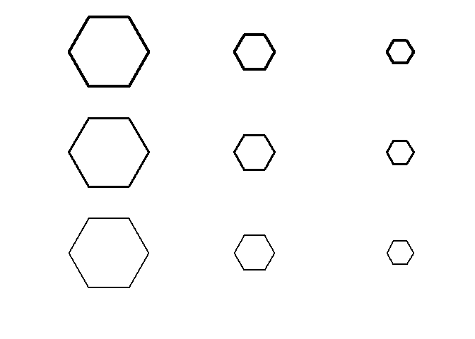

```r
lwds_vh = apply(Raven(st1=e.hexagon(),
                  hrule=c("size"),
                  vrule=c("lwd")))
draw(lwds_vh)
```

# LTY * Rotation

## HV - SI

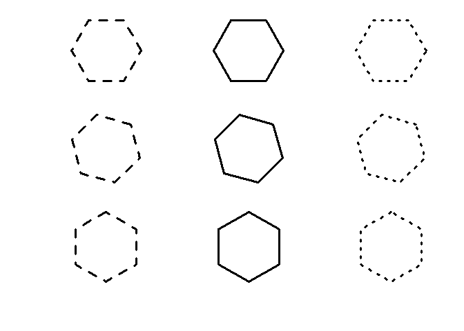

```r
ltyr_hv = apply(Raven(st1=e.hexagon(),
                  hrule=c("lty"),
                  vrule=c("rotation")))
draw(ltyr_hv)
```

## VH - SI

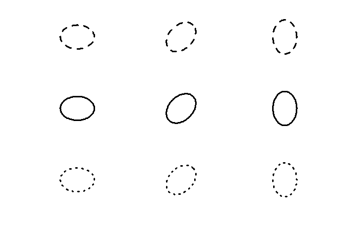

```r
ltyr_vh = apply(Raven(st1=ellipse(),
                  hrule=c("rotation"),
                  vrule=c("lty")))
draw(ltyr_vh)
```

# lty * size

## HV - SI

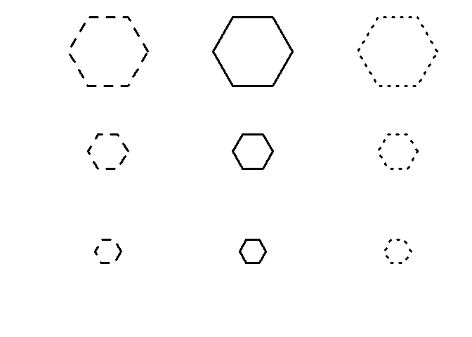

```r
ltys_hv = apply(Raven(st1=e.hexagon(),
                  hrule=c("lty"),
                  vrule=c("size")))
draw(ltys_hv)
```

## VH - SI

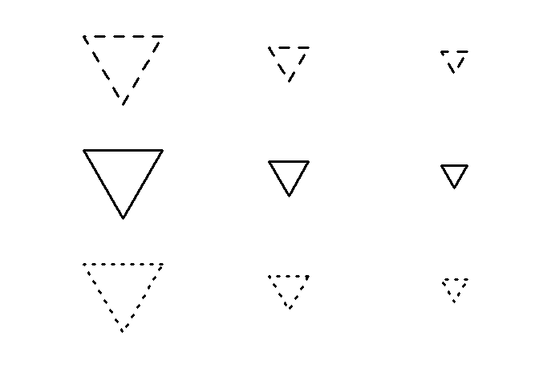

```r
ltys_vh = apply(Raven(st1=triangle(),
                  hrule=c("size"),
                  vrule=c("lty")))
draw(ltys_vh)
```

# Shapes

## H - Si

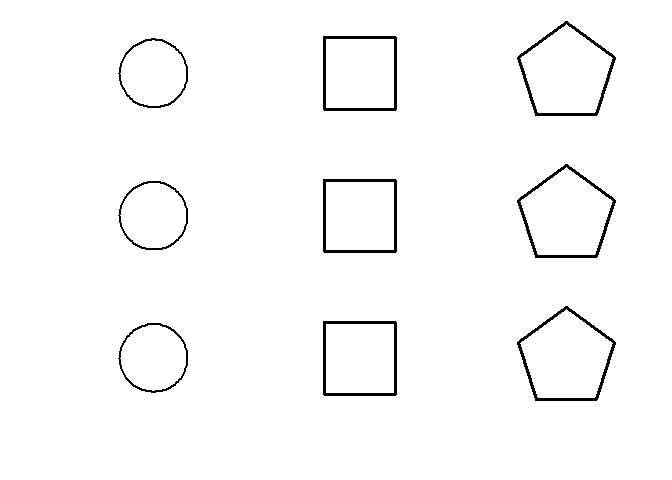

```r
#Horizontal
M<-apply(Raven(st1=cof(circle(),square(),pentagon()),hrule=c("diff_shapes"),vrule=c("identity")))
draw(M)
```

## V - SI

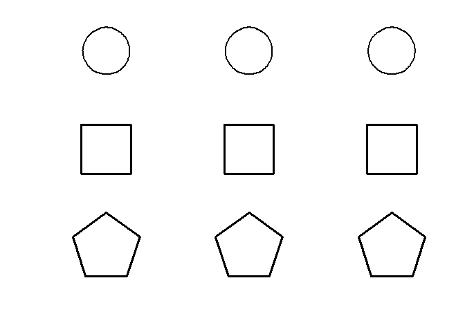

```r
#Vertical
M<-apply(Raven(st1=cof(circle(),square(),pentagon()),hrule=c("identity"),vrule=c("diff_shapes")))
draw(M)
```

## HV - SI

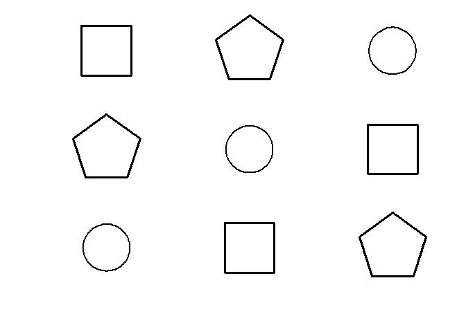

```r
# Top Left Low Right
M<-apply(Raven(st1=cof(circle(),square(),pentagon()),hrule=c("diff_shapes"),vrule=c("diff_shapes")))
draw(M)
```

Il problema di shapes è che non funziona con alcune delle forme

### circle(), triangle(), pentagon() - SI

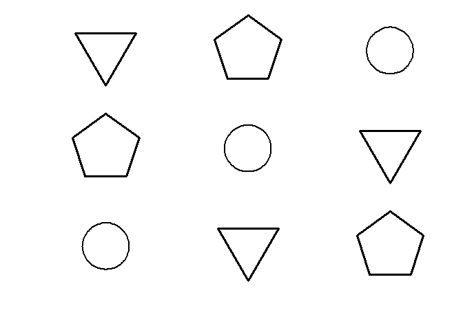

```r
M<-apply(Raven(st1=cof(circle(), triangle(), pentagon()),hrule=c("diff_shapes"),vrule=c("diff_shapes")))
draw(M)
```

### circle(), ellipse(), pentagon() - SI

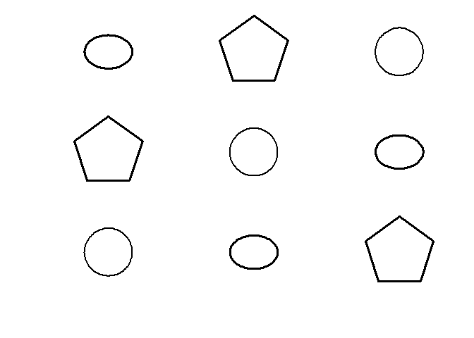

```r
M<-apply(Raven(st1=cof(circle(), ellipse(), pentagon()),hrule=c("diff_shapes"),vrule=c("diff_shapes")))
draw(M)
```

### circle(), ellipse(), e.hexagon() - SI

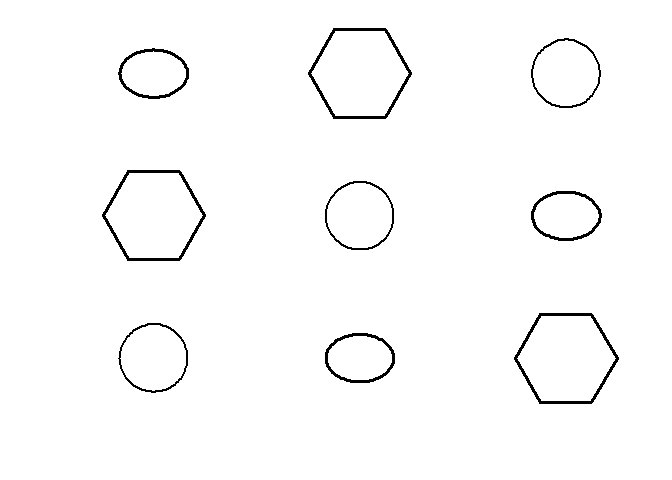

```r
M<-apply(Raven(st1=cof(circle(), ellipse(), e.hexagon()),hrule=c("diff_shapes"),vrule=c("diff_shapes")))
draw(M)
```

### circle(), ellipse(), lily() - NO

```r
Ma<-apply(Raven(st1=cof(circle(), ellipse(), lily()),hrule=c("diff_shapes"),vrule=c("diff_shapes")))
draw(Ma)
```

### circle(), ellipse(), star() - NO

```r
Mb<-apply(Raven(st1=cof(circle(), ellipse(), star()),hrule=c("diff_shapes"),vrule=c("diff_shapes")))
draw(Mb)
```

### circle(), ellipse(), v.arc.left.down() - SI

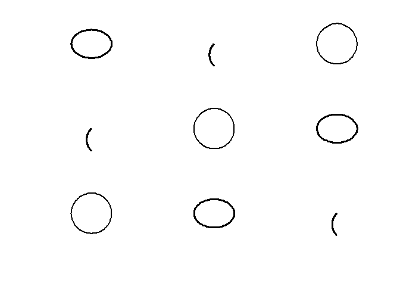

```r
M<-apply(Raven(st1=cof(circle(), ellipse(), v.arc.left.down()),hrule=c("diff_shapes"),vrule=c("diff_shapes")))
draw(M)
```

### (v.arc.right.down(), h.arc.right.down(), v.arc.left.down() - SI

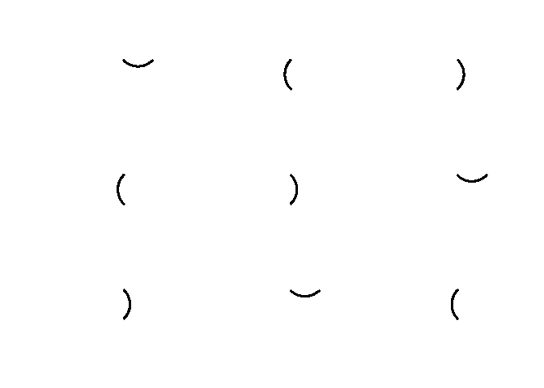

```r
M<-apply(Raven(st1=cof(v.arc.right.down(), h.arc.right.down(), v.arc.left.down()),hrule=c("diff_shapes"),vrule=c("diff_shapes")))
draw(M)
```

Gli archetti funzionano tutti